# Lab: R Plotting with ggplot2

Xuemao Zhang

June 25, 2019

## Introduction

- All [ggplot2](https://ggplot2.tidyverse.org/reference/) plots begin with a call to `ggplot()`, supplying default data and aesthethic mappings, specified by `aes()`. To save a plot to disk, use `ggsave()`. For function references, please see https://ggplot2.tidyverse.org/reference/.
- In this session, we analyze the `Salaries` data from the R library `car`. We use `ggplot2` to plot some basic graphs.
- The data are about 2008-09 nine-month academic salary for Assistant Professors, Associate Professors and Professors in a college in the U.S.
- It is a data frame with 397 observations on the following 6 variables.
  - `rank`: a factor with levels `AssocProf`, `AsstProf`, and `Prof`
  - `discipline`: a factor with levels A (“theoretical”" departments) or B (“applied”" departments).
  - `yrs.since.phd`: years since PhD.
  - `yrs.service`: years of service.
  - `sex`: a factor with levels `Female` and `Male`
  - `salary`: nine-month salary, in dollars.
- Install the following packages if you don’t have them.

```
                install.packages('ggplot2');
                install.packages('car');
                install.packages('gridExtra');
                install.packages('GGally');
```

## Data summary

```r
library(ggplot2);
library(car);
str(Salaries);
```

```
## 'data.frame':    397 obs. of  6 variables:
##  $ rank         : Factor w/ 3 levels "AsstProf","AssocProf",..: 3 3 1 3 3 2 3 3 3 3 ...
##  $ discipline   : Factor w/ 2 levels "A","B": 2 2 2 2 2 2 2 2 2 2 ...
##  $ yrs.since.phd: int  19 20 4 45 40 6 30 45 21 18 ...
##  $ yrs.service  : int  18 16 3 39 41 6 23 45 20 18 ...
##  $ sex          : Factor w/ 2 levels "Female","Male": 2 2 2 2 2 2 2 2 2 1 ...
##  $ salary       : int  139750 173200 79750 115000 141500 97000 175000 147765 119250 129000 ...
```

```r
head(Salaries);
```

```
##        rank discipline yrs.since.phd yrs.service  sex salary
## 1      Prof          B            19          18 Male 139750
## 2      Prof          B            20          16 Male 173200
## 3  AsstProf          B             4           3 Male  79750
## 4      Prof          B            45          39 Male 115000
## 5      Prof          B            40          41 Male 141500
## 6 AssocProf          B             6           6 Male  97000
```

```r
tail(Salaries);
```

```
##         rank discipline yrs.since.phd yrs.service  sex salary
## 392     Prof          A            30          19 Male 151292
## 393     Prof          A            33          30 Male 103106
## 394     Prof          A            31          19 Male 150564
## 395     Prof          A            42          25 Male 101738
## 396     Prof          A            25          15 Male  95329
## 397 AsstProf          A             8           4 Male  81035
```

```r
summary(Salaries);
```

```
##         rank     discipline yrs.since.phd    yrs.service        sex
##  AsstProf : 67   A:181      Min.   : 1.00   Min.   : 0.00   Female: 39
##  AssocProf: 64   B:216      1st Qu.:12.00   1st Qu.: 7.00   Male  :358
##  Prof     :266              Median :21.00   Median :16.00
##                             Mean   :22.31   Mean   :17.61
##                             3rd Qu.:32.00   3rd Qu.:27.00
##                             Max.   :56.00   Max.   :60.00
##      salary
##  Min.   : 57800
##  1st Qu.: 91000
##  Median :107300
##  Mean   :113706
##  3rd Qu.:134185
##  Max.   :231545
```

## Quizk plots

### Bar charts

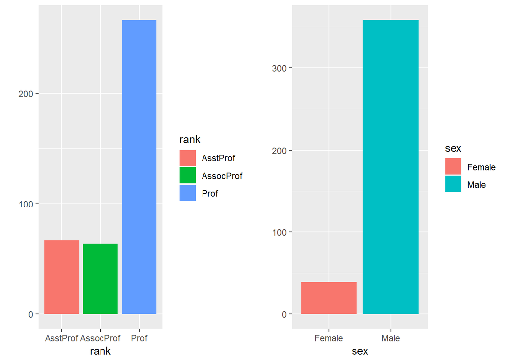

```r
library(gridExtra);
bar1=qplot(data=Salaries,rank, fill=rank);
bar2=qplot(data=Salaries,sex, fill=sex);
grid.arrange(bar1, bar2, ncol=2);
```

### Histograms

- The distribution of the salary variable.

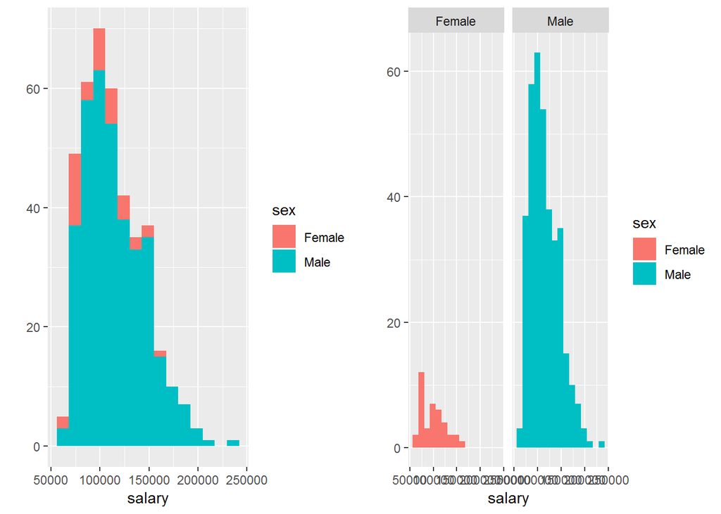

```r
library(gridExtra);
p1 = qplot(data =Salaries, salary, fill = sex, bins = 15);
p2 = qplot(data =Salaries, salary, facets = .~sex, fill = sex, bins=15);
grid.arrange(p1,p2, ncol=2);
```

## Ggplot() Graphics

### Histogram with density scale

- The distribution of the salary variable.

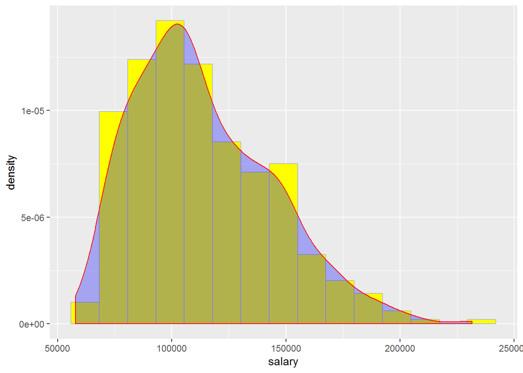

```r
ggplot(data=Salaries,aes(x = salary))+
  geom_histogram(aes(y=..density..),color='grey', fill='yellow',bins=15)+ # Histogram with density instead of count on y-axis
  geom_density(color='red', fill='blue',alpha=0.3); # Overlay with transparent density plot; alpha specifies the transparency level
```

- We may want to make multiple histograms or density curves by group

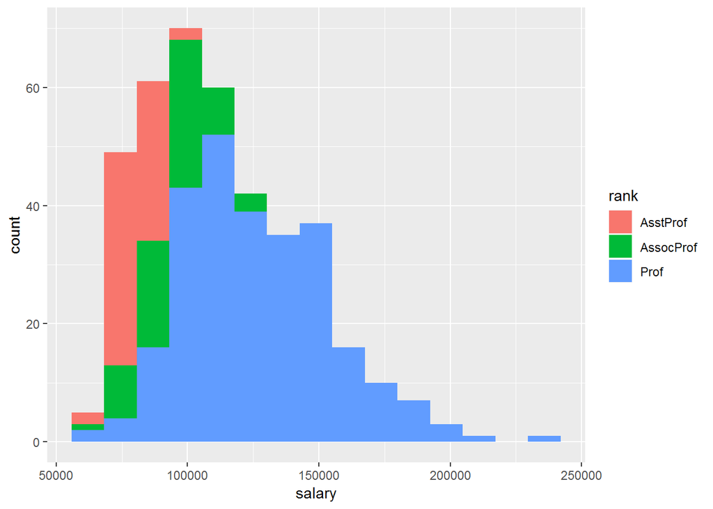

```r
ggplot(data=Salaries,aes(x = salary, fill=rank) )+
  geom_histogram(bins=15);
```

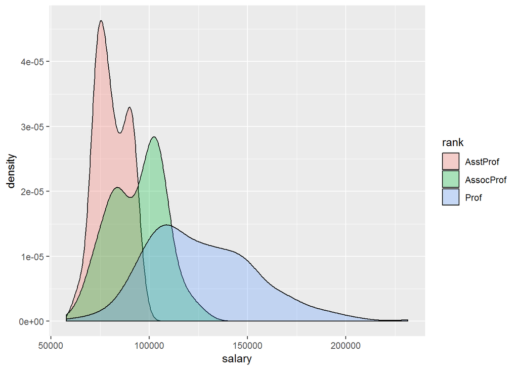

```r
ggplot(data=Salaries,aes(x = salary, fill=rank) )+
  geom_density(alpha=0.3);
```

### Boxplots

- We may compare the three subdata sets using box plots.

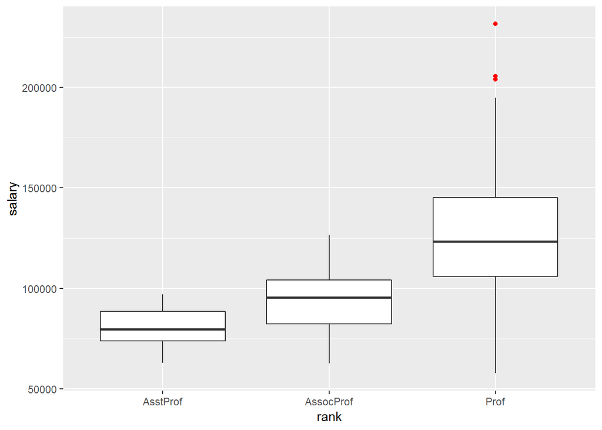

```r
ggplot(data=Salaries,aes(x=rank, y = salary) )+
  geom_boxplot(outlier.color = 'red');  #specify the color of the outliers
```

### Scatter plots

- For example, we use a scatter plot to check the relationship between `salary` and `yrs.service`.

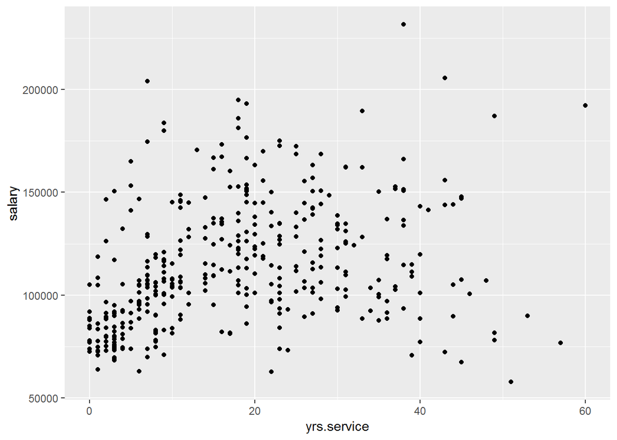

```r
ggplot(data=Salaries,aes(x=yrs.service, y = salary) )+
  geom_point();
```

- We can assign the `sex` to a fill variable.

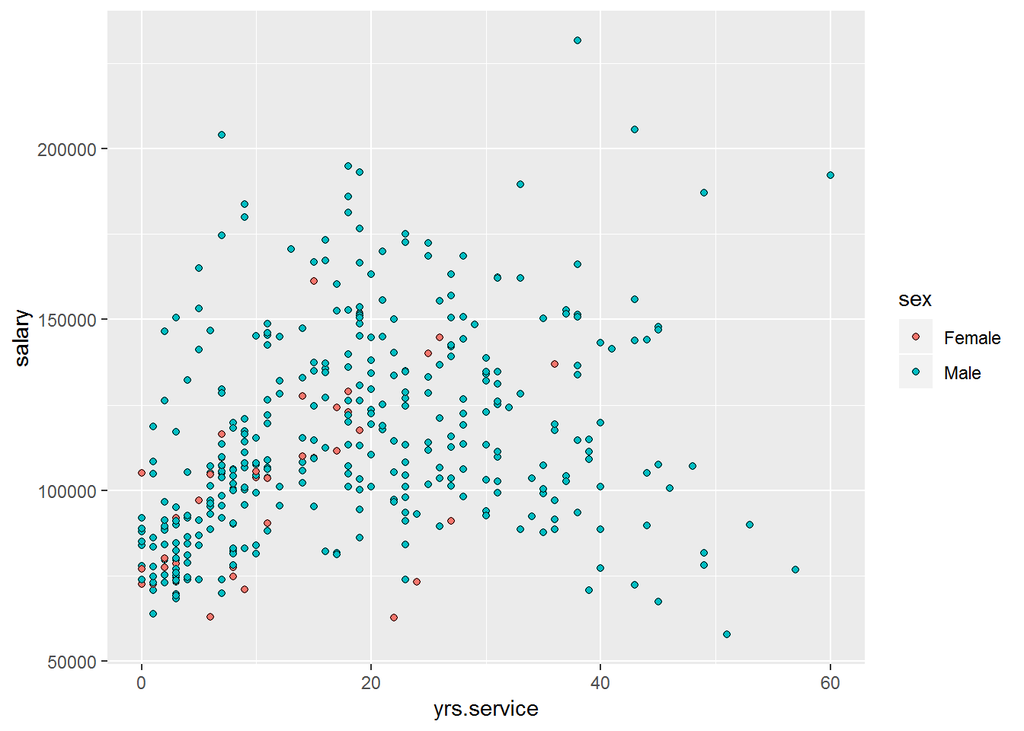

```r
ggplot(data=Salaries,aes(x=yrs.service, y = salary, fill=sex) )+ #assign color variables
  geom_point(pch=21);
```

- Or we can assign the `rank` to a fill variable.

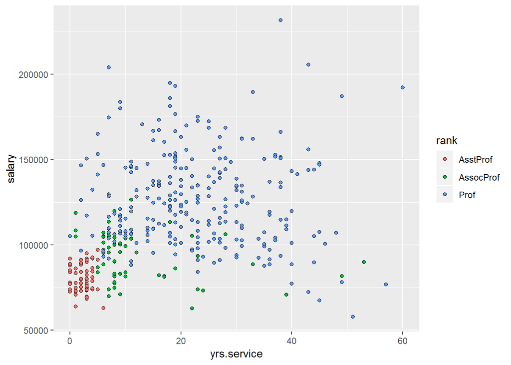

```r
ggplot(data=Salaries,aes(x=yrs.service, y = salary, fill=rank) )+ #assign color variables
  geom_point(pch=21);
```

### Scatter plots with regression line

- There is curvilinear relationship between `salary` and `yrs.service`. We add a smooth regression curve to the scatter plot.

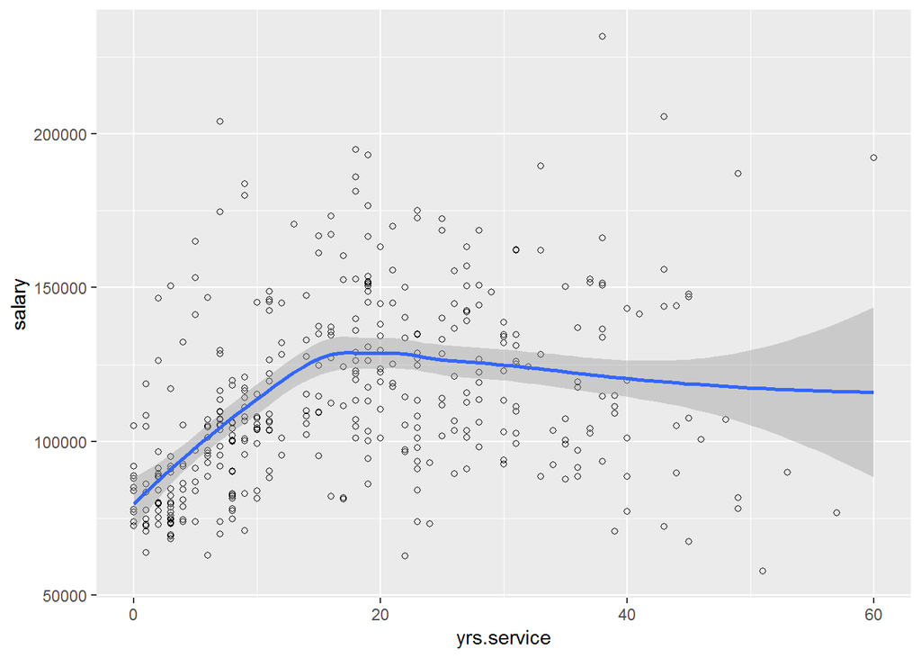

```r
ggplot(data=Salaries,aes(x=yrs.service, y = salary) )+
  geom_point(pch=21) +
  geom_smooth();
```

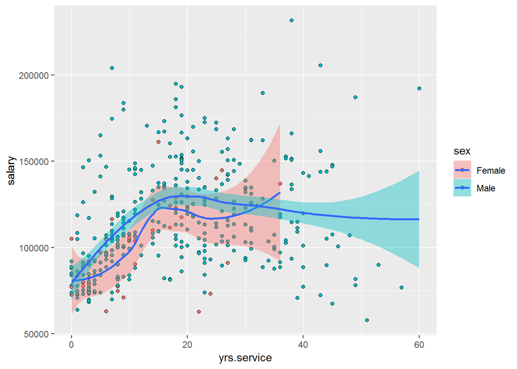

```r
ggplot(data=Salaries,aes(x=yrs.service, y = salary,fill=sex) )+
  geom_point(pch=21) +
  geom_smooth();
```

### Scatter plots with regression line: Facets

- We may consider the relationship between `salary` and `yrs.service` for Female and male, respectively.

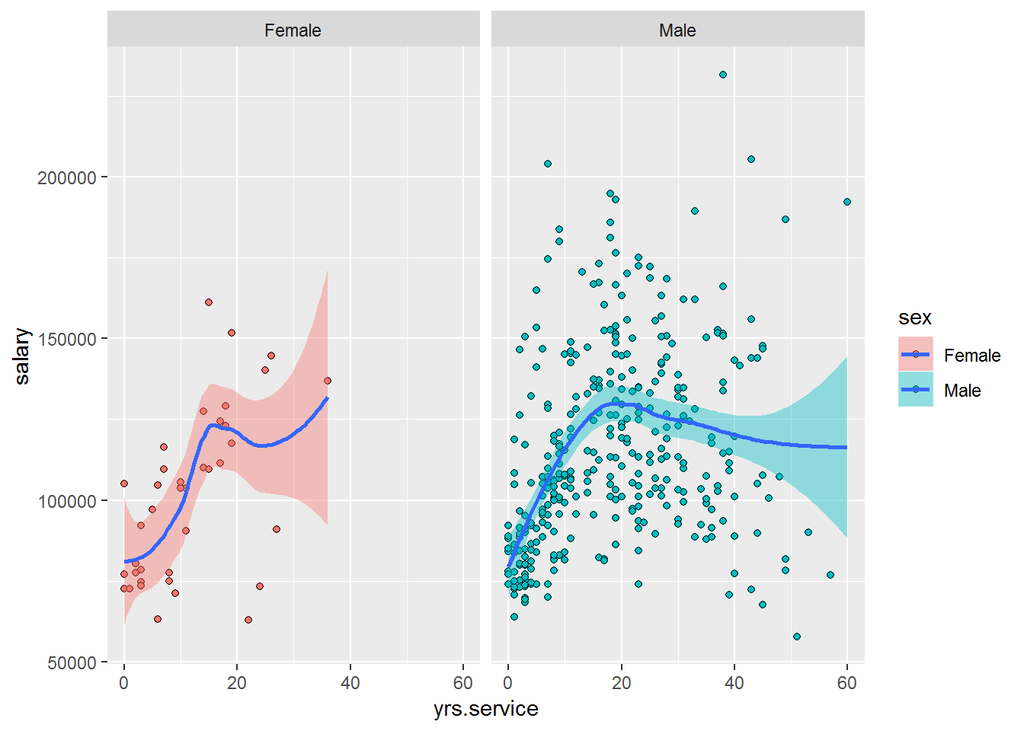

```r
ggplot(data=Salaries,aes(x=yrs.service, y = salary, fill=sex) )+
  geom_point(pch=21) +
  geom_smooth()+
  facet_grid(~sex); #facets by sex
```

- We may consider facets by `rank`.

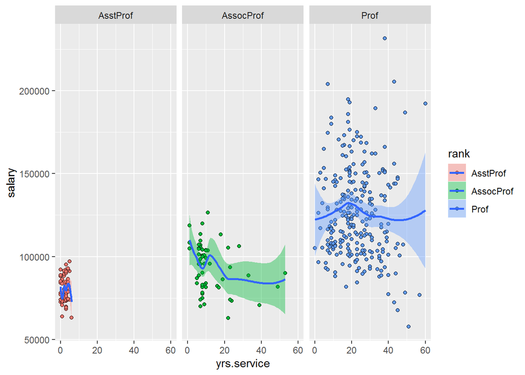

```r
ggplot(data=Salaries,aes(x=yrs.service, y = salary, fill=rank) )+
  geom_point(pch=21) +
  geom_smooth()+
  facet_grid(~rank); #facets by rank
```

## GGally R package

- [GGally](https://cran.r-project.org/web/packages/GGally/GGally.pdf) R package extends ‘ggplot2’ by adding several functions to reduce the complexity of combining geometric objects with transformed data. For example, pairwise plot matrix.
- The package is maintained by [Barret Schloerke](http://ggobi.github.io/ggally/#ggally).
- The function `ggpairs()` produces a matrix of scatter plots for visualizing the correlation between variables.
- The function `ggcorr()` is used to make a nice correlation matrix plot.

### ggpairs(): ggplot2 matrix of plots

```r
library(GGally);
```

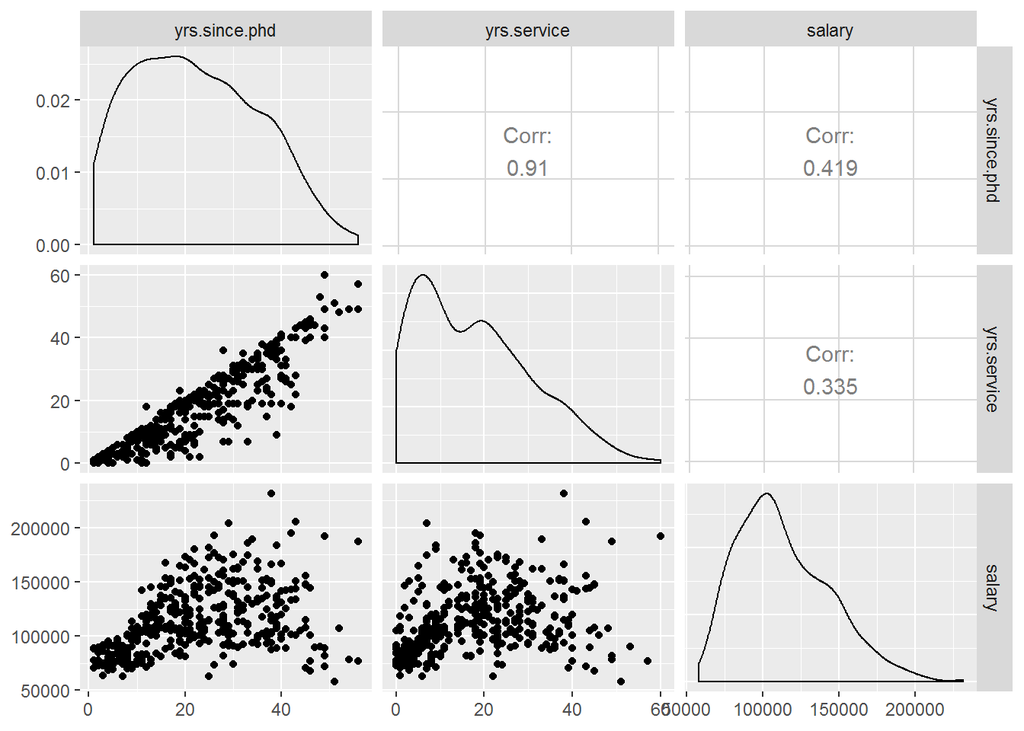

```r
data1=subset(Salaries, select=c("yrs.since.phd", "yrs.service", "salary"));
data2=subset(Salaries, select=c("yrs.since.phd", "yrs.service", "salary","sex"));
ggpairs(data1);
```

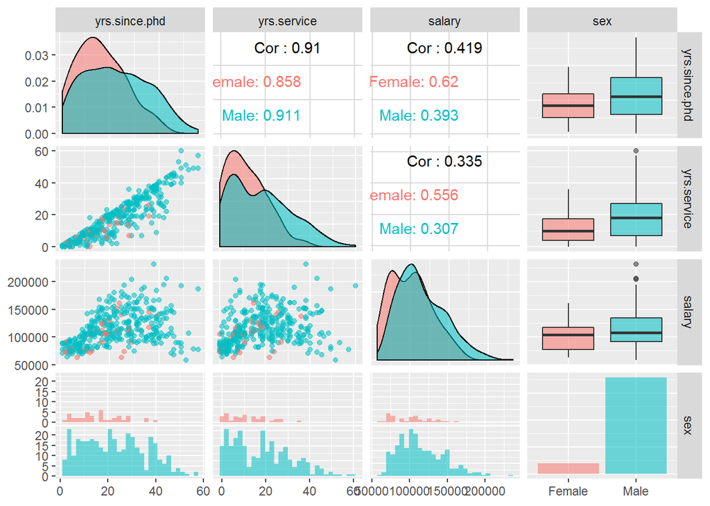

```r
ggpairs(data2, aes(color=sex,alpha = 0.4));
```

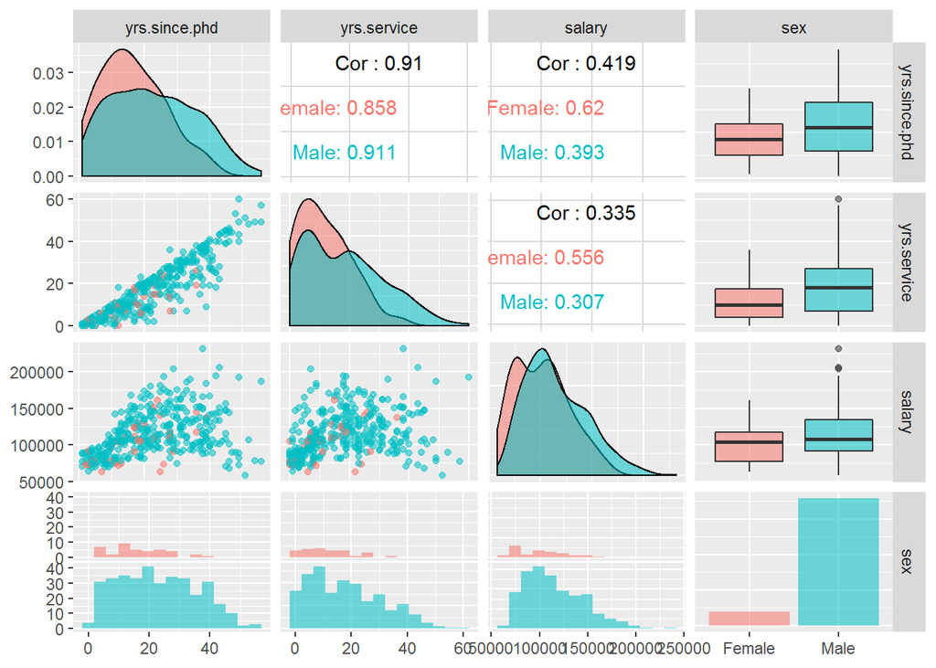

```r
## Remove binwidth warning from ggplot2
ggpairs(data2, aes(color=sex,alpha = 0.4), lower=list(combo = wrap("facethist", bins=15)) );
```

### Correlation matrix with GGally

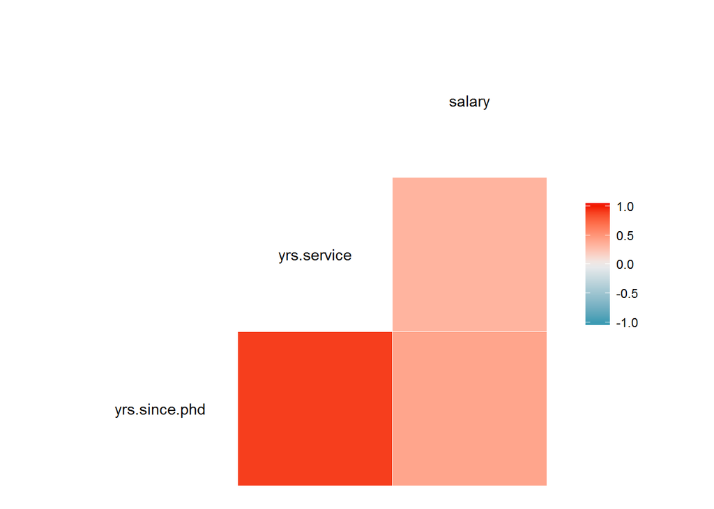

```r
library(GGally);
ggcorr(data1);
```